# Day 2 - R, RStudio, R Markdown, Workflow and Github

28. June

## What we’ll cover today

- Why use R
- Setting up a Github repository
- Installing R and RStudio
- Introduction to programming in R

## Questions

Where do you plan to communicate?

- Teams?
- Canvas?
- Messenger?
- Slack?
- Discord?

How many have installed R and RStudio already?

## Why use R?

- R is free
- R enhances reproducibility
- R makes it easier to spot errors
- R offers a large and supportive community to help you, both on the web and in real life
- R is tailored for statistical analysis

## R and RStudio

- R is the engine
- RStudio is the car

[figure not shown]

## Github

**Why?**

- It makes collaboration easier.
- It gives your work exposure and publicity.
- It can be an important component in integration with other platforms.

## Github: Registering an account

1. Open https://github.com in a web browser, and then select Sign up.
2. Enter your email address.
3. Create a password for your new GitHub account, and Enter a username, too. Next, choose whether you want to receive updates and announcements via email, and then select Continue.
4. Verify your account by solving a puzzle. Select the Start Puzzle button to do so, and then follow the prompts.
5. After you verify your account, select the Create account button.
6. Next, GitHub sends a launch code to your email address. Type that launch code in the Enter code dialog, and then press Enter.
7. GitHub asks you some questions to help tailor your experience. Choose the answers that apply to you.
8. On the “Where teams collaborate and ship” screen, you can choose whether you want to use the Free account or the Team account. To choose the Free account, select the Skip personalization button.
9. GitHub opens a personalized page in your browser.

## Github: Creating a repository

1. Click on your profile button in the right hand corner of your Github screen and choose “Your repositories”.
2. Click the green button “New”.
3. Type a short, memorable name for your repository.
4. Optionally, add a description of your repository.
5. Choose a repository visibility. Here, you can pick “Public”.
6. Under “Initialize this repository with”, choose “Add a README file”.
7. Click “Create repository”.

## Github: Add collaborators to repository

1. Collect the Github usernames for the rest of the team.
2. Navigate to the main page of the repository.
3. Under your repository name, click Settings.
4. In the “Access” section of the sidebar, click “Collaborators”.
5. Click “Add people”.

## Installing R and RStudio

**R**: www.r-project.org

**RStudio**: www.rstudio.com

## How RStudio works

[figure not shown]

## Git operations

- git pull
- git add
- git commit
- git push

## Paths and folders

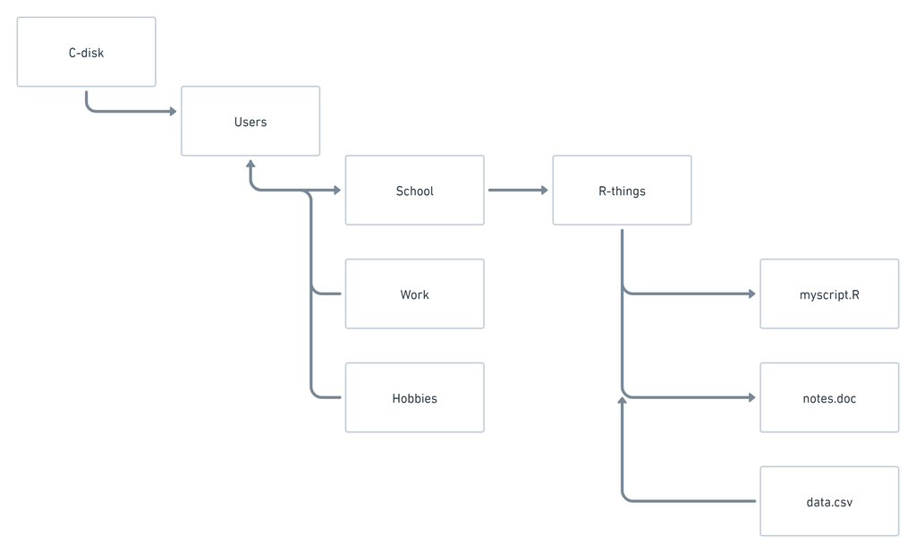

## What is R Markdown?

- YAML header
- Headers
- Text (+ bold, italics, code)
- Coding chunks
- Settings for coding chunks

eval = FALSE echo = FALSE message = FALSE warning = FALSE error = FALSE

## Objects in R

- Assigning values to objects
- Different data types

| Data type | Properties |
| --- | --- |
| `numeric` | contains decimal and whole numbers, also called “double” |
| `integer` | contains only whole numbers |
| `character` | contains character strings (“words”) |
| `factor` | contains categories (either ranked or unranked) |
| `logical` | contains only two values, TRUE and FALSE |

## Objects in R

- Different object types

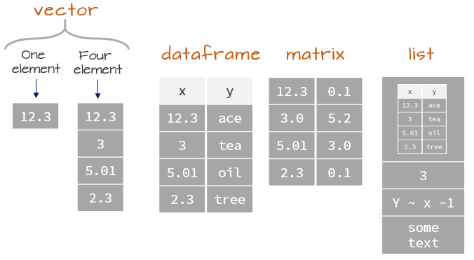

## Packages

```r
install.packages("tidyverse")
library(tidyverse)
```

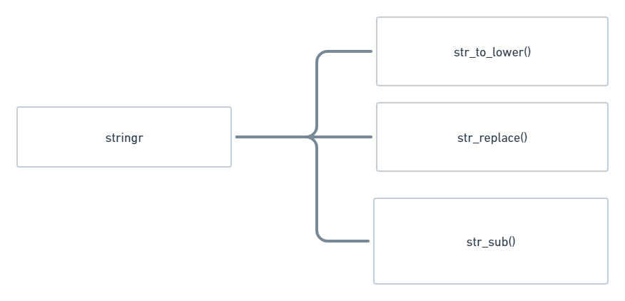

## LaTex

```r
install.packages("tinytex")
install_tinytex()
```

## Functions

```r
sum(10, 10)
```

```
## [1] 20
```

```r
mean(10, 10)
```

```
## [1] 10
```

```r
str_to_lower("THIS IS A SENTENCE")
```

```
## [1] "this is a sentence"
```